# Identify Customer Segments for Mail-order Sales company

### Unsupervised Learning / Principle Component Analysis / K-Means

In this project, unsupervised learning techniques will be applied to identify segments of the population that form the core customer base for a mail-order sales company in Germany. These segments can then be used to direct marketing campaigns towards audiences that will have the highest expected rate of returns.

The data that will be used has been provided by Bertelsmann Arvato Analytics, and represents a real-life data science task.

```python
import numpy as np
import pandas as pd

import matplotlib.pyplot as plt
import matplotlib.image as mpimg
import matplotlib.cm as cm
import seaborn as sns
%matplotlib inline
```

```python
from sklearn.preprocessing import Imputer
from sklearn.preprocessing import StandardScaler
from sklearn.model_selection import train_test_split
from sklearn.metrics import confusion_matrix, accuracy_score
from sklearn.decomposition import PCA
from sklearn.cluster import KMeans
from sklearn.datasets import make_blobs
from functools import reduce
```

```python
from mpl_toolkits.mplot3d import Axes3D
from IPython import display
```

### Step 0: Load the Data

There are four files associated with this project (not including this one):

- `Udacity_AZDIAS_Subset.csv`: Demographics data for the general population of Germany; 891211 persons (rows) x 85 features (columns).
- `Udacity_CUSTOMERS_Subset.csv`: Demographics data for customers of a mail-order company; 191652 persons (rows) x 85 features (columns).
- `Data_Dictionary.md`: Detailed information file about the features in the provided datasets.
- `AZDIAS_Feature_Summary.csv`: Summary of feature attributes for demographics data; 85 features (rows) x 4 columns

Each row of the demographics files represents a single person, but also includes information outside of individuals, including information about their household, building, and neighborhood. This information will be used to cluster the general population into groups with similar demographic properties.

Then steps would be taken to decide how the people in the customers dataset fit into those created clusters. **The hope here is that certain clusters are over-represented in the customers data, as compared to the general population; those over-represented clusters will be assumed to be part of the core userbase. This information can then be used for further applications, such as targeting for a marketing campaign.**

```python
# Load in the general demographics data.
azdias = pd.read_csv('Udacity_AZDIAS_Subset.csv', delimiter=';')
```

```python
# Load in the feature summary file.
feat_info = pd.read_csv('AZDIAS_Feature_Summary.csv', delimiter=';')
```

```python
azdias.tail(2)
```

|  | AGER_TYP | ALTERSKATEGORIE_GROB | ANREDE_KZ | CJT_GESAMTTYP | FINANZ_MINIMALIST | FINANZ_SPARER | FINANZ_VORSORGER | FINANZ_ANLEGER | FINANZ_UNAUFFAELLIGER | FINANZ_HAUSBAUER | ... | PLZ8_ANTG1 | PLZ8_ANTG2 | PLZ8_ANTG3 | PLZ8_ANTG4 | PLZ8_BAUMAX | PLZ8_HHZ | PLZ8_GBZ | ARBEIT | ORTSGR_KLS9 | RELAT_AB |
| --- | --- | --- | --- | --- | --- | --- | --- | --- | --- | --- | --- | --- | --- | --- | --- | --- | --- | --- | --- | --- | --- |
| 891219 | -1 | 1 | 1 | 3.0 | 1 | 5 | 3 | 5 | 5 | 5 | ... | 1.0 | 4.0 | 3.0 | 1.0 | 5.0 | 1.0 | 1.0 | 4.0 | 7.0 | 5.0 |
| 891220 | -1 | 4 | 1 | 1.0 | 4 | 2 | 5 | 2 | 1 | 5 | ... | 3.0 | 3.0 | 1.0 | 0.0 | 1.0 | 4.0 | 4.0 | 3.0 | 4.0 | 5.0 |

2 rows × 85 columns

## Step 1: Preprocessing

### Step 1.1: Assess Missing Data

The feature summary file contains a summary of properties for each demographics data column. This file will be used to help make cleaning decisions during this stage of the project.

The demographics data will first be assessed to find missing data.

```python
#azdias.isnull().sum()
```

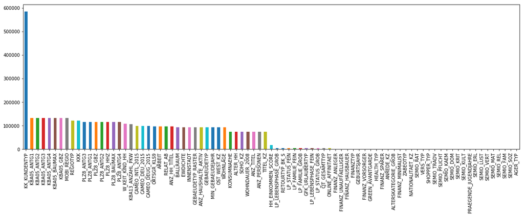

```python
azdias.isnull().sum().sort_values(ascending =False).plot.bar(figsize=(20,6))
```

```python
val = azdias.isnull().sum().sort_values(ascending =False)
print('Features with the top most null values')
val[:15]
```

```
Features with the top most null values
```

```
KK_KUNDENTYP    584612
KBA05_ANTG1     133324
KBA05_ANTG2     133324
KBA05_ANTG3     133324
KBA05_ANTG4     133324
KBA05_BAUMAX    133324
KBA05_GBZ       133324
MOBI_REGIO      133324
REGIOTYP        121196
KKK             121196
PLZ8_ANTG3      116515
PLZ8_ANTG1      116515
PLZ8_GBZ        116515
PLZ8_ANTG2      116515
PLZ8_HHZ        116515
dtype: int64
```

#### Step 1.1.1: Convert Missing Value Codes to NaNs

The fourth column of the feature attributes summary (loaded in above as `feat_info`) documents the codes from the data dictionary that indicate missing or unknown data. While the file encodes this as a list (e.g. `[-1,0]`), this will get read in as a string object.

Parsing is done to make use of it to identify and clean the data. Data that matches a 'missing' or 'unknown' value code is converted into a numpy NaN value.

```python
def covert_Nan(df2):
    df = df2.copy(deep=True)
    for row, feature_col in enumerate(df.iteritems()):
        col_name = feature_col[0]
        NaN_values = feat_info['missing_or_unknown'][row]
        NaN_values = NaN_values.replace(']','').replace('[','')
        NaN_values = NaN_values.replace('"','').split(",")
        NaN_values1 = []
        #print(col_name, NaN_values)
        if(len(NaN_values)==1 and NaN_values[0]==''):
            pass
        else:
            for i in NaN_values:
                if i in ['X', 'XX']:
                    NaN_values1.append(i)
                else:
                    NaN_values1.append(int(i))
                    #print(NaN_values1)
            df[col_name] = df[col_name].replace(NaN_values1,np.nan)
    return df
```

```python
azdias = covert_Nan(azdias)
```

```python
no_of_null_initial = azdias.isnull().sum().sum()
print('Null', no_of_null_initial)
```

```
Null 8373929
```